# Implemeting GWR Using nimble

This webpage is created as an online supplemental material for the manuscript **Geographically Weighted Regression Analysis for Spatial Economics Data: a Bayesian Recourse**.

### Generate Simulated Dataset

We use the spatial structure of Louisiana counties as a illustration. There are 64 counties in total. In our simulated data, each county has three observations. Therefore, let us define the constants, and simulate an artificial dataset.

```r
N <- 192
S <- 64

mybeta <- c(2, 0, 0, 4, 8)
set.seed(1)
x1 <- rnorm(192);
x2 <- rnorm(192);
x3 <- rnorm(192);
x4 <- rnorm(192);
x5 <- rnorm(192);
y  <- cbind(x1, x2, x3, x4, x5) %*% mybeta + rnorm(192)
## replicate y 192 times to make a square matrix for easy implementation
y <- matrix(y, nrow = length(y), ncol = length(y), byrow = FALSE)
```

### Code in `nimble`

#### Main Function

To obtain the posterior estimates of the proposed GWR model, MCMC algorithms should be used for sampling from the corresponding posterior distributions of the parameters. The development of software and computation techniques simplify the implementation of complex models. A brief introduction of some existing programs and software can be seen in Ma and Chen (2019). In this paper, we use the powerful `R` package **nimble** (Valpine et al. 2017) and briefly introduce how to implement the proposed Bayesian GWR model with `nimble` 0.7.0 in `R` 3.4.1. A nimble model contains four parts including the model code, the constants, the data, and the initial values for MCMC. Syntax of the model code is similar to the `BUGS` language. For illustration, here we define S as the number of locations, N as the number of observations, and p = 5 as the dimension of the covariates vector. For defining the model, the function `nimbleCode()` in the **nimble** package is used:

```r
library(nimble)

GWRCode <- nimbleCode({
    for (i in 1:S) {
        y[1:N, i] ~ dmnorm(mu_y[1:N, i], prec = tau_y0[1:N, 1:N, i])
        mu_y[1:N, i] <- b[i, 1] * x1[1:N] + b[i, 2] * x2[1:N] + b[i, 3] *
            x3[1:N] + b[i, 4] * x4[1:N] + b[i, 5] * x5[1:N]
        tau_y0[1:N, 1:N, i] <- diag(psi_y[i] * exp(-Dist[1:N, i]/lambda))
        for (j in 1:5) {
            b[i, j] ~ dnorm(0, tau = tau_b[ind[j] + 1])
            ind[j] ~ dbern(gamma[j])
            tau_b[1] <- tau_b0
            tau_b[2] <- tau_b0 * c
            gamma[j] ~ dbeta(0.5, 0.5)
        }
        b0[i] ~ dnorm(0, 1)
        psi_y[i] ~ dgamma(1, 1)
    }
    lambda ~ dunif(0, D)
})
```

Lines 3-8 represent Equation (17), where `dmnorm` denotes the multivariate normal distribution with mean `mu_y` and precision `tau_y0`. In the expression of `tau_y0`, `psi_y[i]` denotes $1 / \sigma^2(s)$ in (17), and `exp(-Dist[1:N, i]/lambda)` denotes the exponential weighting scheme with the distance matrix `Dist` and the bandwidth `lambda`.

Lines 9-15 represent thespike and slab prior of the coefficients $\beta_j(s)$ in Equation (18), where `ind[j]` defines the distribution of `b[i, j]`. When `ind[j] = 0`, the precision of `b[i, j]` is `tau_b0`, otherwise the precision is `tau_b0 * c`. Lines 16-20 give the priors of the intercept, the precision of the responses, and the bandwidth of the weighting function.

#### Data List for Model

The second part is to declare the data list for the above model code, which consists of the response variable, the covariates and the distance matrix (provided as a separate `.rds`).

```r
netdist <- readRDS("./LAGDist.rds")
## Repeat the distance matrix three times as there are three observations
## per county
dist2 <- rbind(netdist, netdist, netdist)

GWRData <- list(y = y, x1 = x1, x2 = x2, x3 = x3, x4 = x4, x5 = x5,
                Dist = dist2)
```

Then we can give the constant list, which contains the constant quantities in the model code. `S` is the number of locations, `N` denotes the number of observations, and `D` correspond to the upper endpoint of the uniform distribution for bandwidth in Equation (22).

```r
GWRConst <- list(S = S, N = N, D = 50, tau_b0 = 100, c = 0.0001)
```

And lastly, we can assign some initial values for the parameters:

```r
GWRInits <- list(psi_y = rep(1, GWRConst$S), ind = c(1, 1, 0, 0, 0),
                 gamma = rep(0.5, 5), lambda = 10)
```

### Run the Model

**nimble** provides an one-line function of MCMC to invoke the MCMC engine directly, which generally take the code, data, constants, and initial values as input, and provides a variety of options for executing and controlling multiple chains, iterations, thinning intervals, etc. The following code runs 1 MCMC chain with 5000 iterations, with the first 2000 as burn-in. Therefore, the returned result will contain 3000 posterior samples for parameters `b`, `psi_y` and `lambda`.

```r
mcmc.out <- nimbleMCMC(code = GWRCode, data = GWRData, constants = GWRConst,
  inits = GWRInits, thin = 1, niter = 5000, nchains = 1, nburnin = 2000,
  monitors = c("b", "psi_y", "lambda"), setSeed = TRUE)
```

### Posterior Convergence Diagnostics and Estimation

The package **coda** (Plummer et al. 2006) provides handy tools for posterior convergence diagnostics, as well as several percentiles of the posterior distribution, which are often of interest in posterior inference.

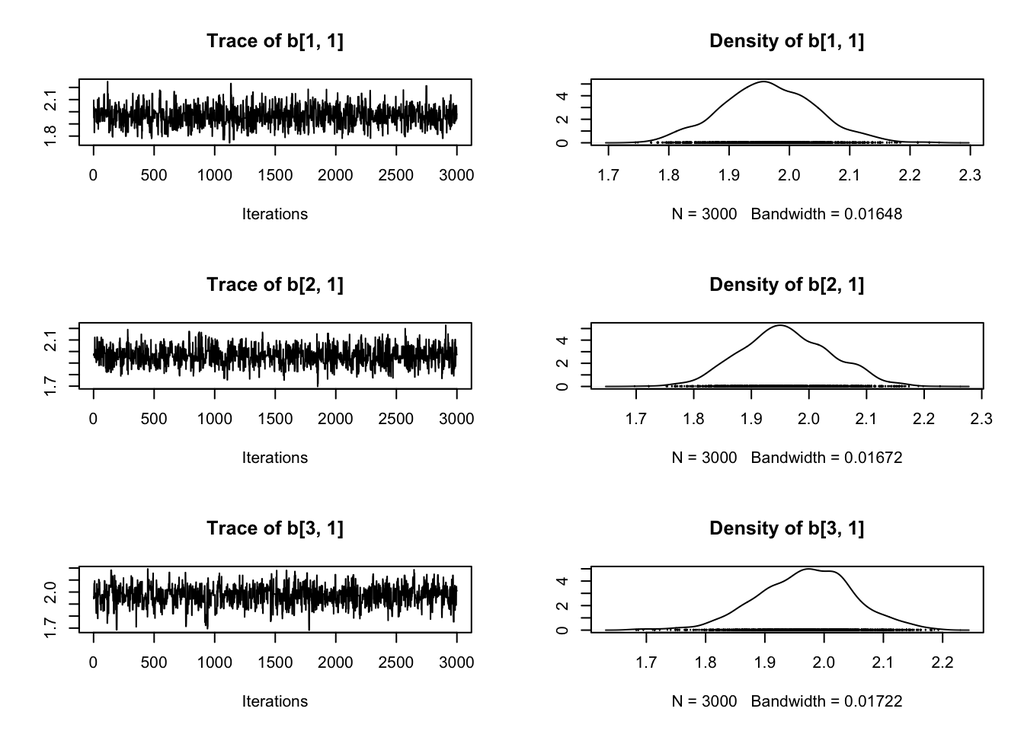

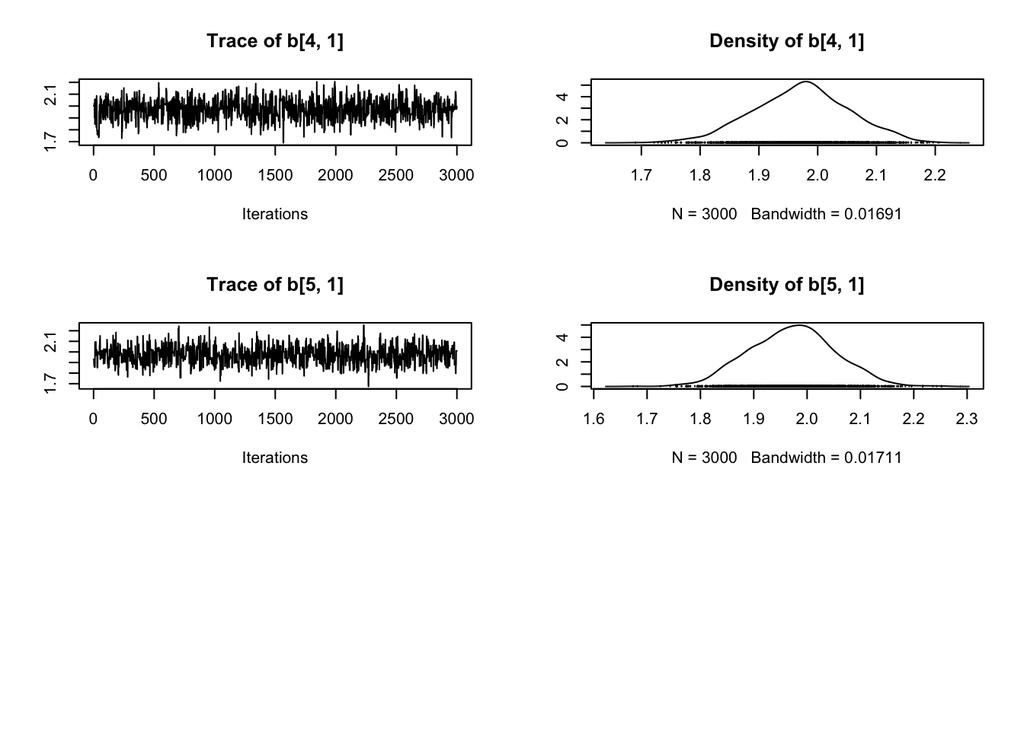

```r
library(coda)
pos_mcmc <- as.mcmc(mcmc.out)

## plot the first five parameter estimates
plot(pos_mcmc[,1:5])
```

```r
pos_summ <- summary(pos_mcmc)
str(pos_summ)
```

```
## List of 6
##  $ statistics: num [1:385, 1:4] 1.97 1.96 1.97 1.97 1.97 ...
##   ..- attr(*, "dimnames")=List of 2
##   .. ..$ : chr [1:385] "b[1, 1]" "b[2, 1]" "b[3, 1]" "b[4, 1]" ...
##   .. ..$ : chr [1:4] "Mean" "SD" "Naive SE" "Time-series SE"
##  $ quantiles : num [1:385, 1:5] 1.81 1.82 1.81 1.81 1.82 ...
##   ..- attr(*, "dimnames")=List of 2
##   .. ..$ : chr [1:385] "b[1, 1]" "b[2, 1]" "b[3, 1]" "b[4, 1]" ...
##   .. ..$ : chr [1:5] "2.5%" "25%" "50%" "75%" ...
##  $ start     : num 1
##  $ end       : num 3000
##  $ thin      : num 1
##  $ nchain    : num 1
##  - attr(*, "class")= chr "summary.mcmc"
```

```r
head(pos_summ$statistics)
```

```
##             Mean         SD    Naive SE Time-series SE
## b[1, 1] 1.965422 0.07761376 0.001417027    0.002734311
## b[2, 1] 1.960653 0.07821801 0.001428059    0.002912826
## b[3, 1] 1.969026 0.08075857 0.001474443    0.003106918
## b[4, 1] 1.971726 0.08100742 0.001478986    0.003072458
## b[5, 1] 1.972051 0.08006170 0.001461720    0.002927044
## b[6, 1] 1.966020 0.07664128 0.001399272    0.002897708
```

```r
head(pos_summ$quantiles)
```

```
##             2.5%      25%      50%      75%    97.5%
## b[1, 1] 1.814306 1.914437 1.964210 2.017787 2.123853
## b[2, 1] 1.816435 1.907082 1.958030 2.014533 2.108694
## b[3, 1] 1.808375 1.916024 1.973355 2.023972 2.126360
## b[4, 1] 1.813411 1.918140 1.974263 2.024164 2.128462
## b[5, 1] 1.823739 1.916236 1.973940 2.024516 2.124304
## b[6, 1] 1.805725 1.917178 1.970740 2.015932 2.114462
```

## References

Ma, Zhihua, and Guanghui Chen. 2019. “Bayesian Semiparametric Latent Variable Model with DP Prior for Joint Analysis: Implementation with nimble.” *Statistical Modelling*. SAGE Publications Sage India: New Delhi, India, 1471082X18810118.

Plummer, Martyn, Nicky Best, Kate Cowles, and Karen Vines. 2006. “CODA: Convergence Diagnosis and Output Analysis for MCMC.” *R News* 6 (1): 7–11. https://journal.r-project.org/archive/.

Valpine, Perry de, Daniel Turek, Christopher J Paciorek, Clifford Anderson-Bergman, Duncan Temple Lang, and Rastislav Bodik. 2017. “Programming with Models: Writing Statistical Algorithms for General Model Structures with NIMBLE.” *Journal of Computational and Graphical Statistics* 26 (2). Taylor & Francis: 403–13.